# EP W5

Name: Syeduzzaman Khan

Project Title: Does SFO require expansion ?

1. Objectives:

   SFO is the largest airport in Northern California and the second-busiest in California. It has flights to points throughout North America and is a major gateway to Europe and Asia. SFO is owned and policed by the City and County of San Francisco, but is in San Mateo County.

   The purpose of this project is to analysis the four different datasets (SF Air Traffic Passenger, Landings Statistics, Airlines, and Countries of the World) and help to San Mateo County to support their airport expansion plan.

   o achieve San Mateo County goals, we have to carefully analyze the dataset considering different perspectives. At the beginning of the project, we will get to familiar with datasets and look into different columns. Then, we will pick the relevant columns that will lead us to reach our goals. The obtained results will be visualized using plot and table.

# 2. Data Exploration:

Read dataset

```r
# read csv file

landings <- read.csv ("air-traffic-landings-statistics.csv", na.strings="",stringsAsFactors=FALSE)

passenger <- read.csv ("air-traffic-passenger-statistics.csv", na.strings="",stringsAsFactors=FALSE)

countries<-read.csv("Countries of the World.csv")

airlines<-read.csv("Airlines.csv")
```

```r
cat("Landings dataset: ")
head(landings)
```

```
Landings dataset:
```

| Activity.Period | Operating.Airline | Operating.Airline.IATA.Code | Published.Airline | Published.Airline.IATA.Code | GEO.Summary | GEO.Region | Landing.Aircraft.Type | Aircraft.Body.Type | Aircraft.Manufacturer | Aircraft.Model | Aircraft.Version | Landing.Count | Total.Landed.Weight |
| --- | --- | --- | --- | --- | --- | --- | --- | --- | --- | --- | --- | --- | --- |
| 200204 | ATA Airlines | TZ | ATA Airlines | TZ | Domestic | US | Passenger | Narrow Body | Boeing | 757 | 200 | 83 | 16434000 |
| 200204 | ATA Airlines | TZ | ATA Airlines | TZ | Domestic | US | Passenger | Narrow Body | Boeing | 757 | 300 | 3 | 672000 |
| 200204 | ATA Airlines | TZ | ATA Airlines | TZ | Domestic | US | Passenger | Wide Body | Lockheed | L1011 | 0 | 27 | 9666000 |
| 200204 | Aeroflot Russian International Airlines | NA | Aeroflot Russian International Airlines | NA | International | Europe | Passenger | Wide Body | Boeing | 777 | 0 | 9 | 4139946 |
| 200204 | Air Canada | AC | Air Canada | AC | International | Canada | Passenger | Narrow Body | Boeing | 737 | 200 | 5 | 525000 |
| 200204 | Air Canada | AC | Air Canada | AC | International | Canada | Passenger | Narrow Body | Boeing | 737 | NA | 15 | 1605000 |

```r
cat("Passenger dataset: ")

head(passenger)
```

```
Passenger dataset:
```

| Activity.Period | Operating.Airline | Operating.Airline.IATA.Code | Published.Airline | Published.Airline.IATA.Code | GEO.Summary | GEO.Region | Activity.Type.Code | Price.Category.Code | Terminal | Boarding.Area | Passenger.Count |
| --- | --- | --- | --- | --- | --- | --- | --- | --- | --- | --- | --- |
| 200507 | ATA Airlines | TZ | ATA Airlines | TZ | Domestic | US | Deplaned | Low Fare | Terminal 1 | B | 27271 |
| 200507 | ATA Airlines | TZ | ATA Airlines | TZ | Domestic | US | Enplaned | Low Fare | Terminal 1 | B | 29131 |
| 200507 | ATA Airlines | TZ | ATA Airlines | TZ | Domestic | US | Thru / Transit | Low Fare | Terminal 1 | B | 5415 |
| 200507 | Air Canada | AC | Air Canada | AC | International | Canada | Deplaned | Other | Terminal 1 | B | 35156 |
| 200507 | Air Canada | AC | Air Canada | AC | International | Canada | Enplaned | Other | Terminal 1 | B | 34090 |
| 200507 | Air China | CA | Air China | CA | International | Asia | Deplaned | Other | International | G | 6263 |

```r
cat("Airlines dataset: ")

head(airlines)
```

```
Airlines dataset:
```

| Name | ICAO | IATA | CallSign | Country | Founded | Destinations | Fleet.Size |
| --- | --- | --- | --- | --- | --- | --- | --- |
| Air Vanuatu | AVN | NF | AIR VAN | Vanuatu | 1981 | 33 | 6 |
| Atlantic Airways | FLI | RC | FAROELINE | Faroe Islands | 1987 | 9 | 5 |
| Express.Net Airlines | XNA |  | EXPRESSNET |  | 1972 | NA | 4 |
| Sabah Air | SAX | SA | SABAH AIR | Malaysia | 1975 | NA | 12 |
| Air Vega |  |  |  |  | 2012 | NA | 1 |
| Corporate Flight Management | VTE |  | VOLUNTEER |  | 1982 | NA | 27 |

```r
cat("Country dataset: ")

head(countries)
```

```
Country dataset:
```

| Country | Region | Population | Area..sq..mi.. | Pop..Density..per.sq..mi.. | Coastline..coast.area.ratio. | Net.migration | Infant.mortality..per.1000.births. | GDP....per.capita. | Literacy.... | Phones..per.1000. | Arable.... | Crops.... | Other.... | Climate | Birthrate | Deathrate | Agriculture | Industry | Service |
| --- | --- | --- | --- | --- | --- | --- | --- | --- | --- | --- | --- | --- | --- | --- | --- | --- | --- | --- | --- |
| Afghanistan | ASIA (EX. NEAR EAST) | 31056997 | 647500 | 48,0 | 0,00 | 23,06 | 163,07 | 700 | 36,0 | 3,2 | 12,13 | 0,22 | 87,65 | 1 | 46,6 | 20,34 | 0,38 | 0,24 | 0,38 |
| Albania | EASTERN EUROPE | 3581655 | 28748 | 124,6 | 1,26 | -4,93 | 21,52 | 4500 | 86,5 | 71,2 | 21,09 | 4,42 | 74,49 | 3 | 15,11 | 5,22 | 0,232 | 0,188 | 0,579 |
| Algeria | NORTHERN AFRICA | 32930091 | 2381740 | 13,8 | 0,04 | -0,39 | 31 | 6000 | 70,0 | 78,1 | 3,22 | 0,25 | 96,53 | 1 | 17,14 | 4,61 | 0,101 | 0,6 | 0,298 |
| American Samoa | OCEANIA | 57794 | 199 | 290,4 | 58,29 | -20,71 | 9,27 | 8000 | 97,0 | 259,5 | 10 | 15 | 75 | 2 | 22,46 | 3,27 |  |  |  |
| Andorra | WESTERN EUROPE | 71201 | 468 | 152,1 | 0,00 | 6,6 | 4,05 | 19000 | 100,0 | 497,2 | 2,22 | 0 | 97,78 | 3 | 8,71 | 6,25 |  |  |  |
| Angola | SUB-SAHARAN AFRICA | 12127071 | 1246700 | 9,7 | 0,13 | 0 | 191,19 | 1900 | 42,0 | 7,8 | 2,41 | 0,24 | 97,35 |  | 45,11 | 24,2 | 0,096 | 0,658 | 0,246 |

## Total landings:

```r
#1.
    #  Domestic Total Landings
    landings_domestic<-landings[landings$GEO.Summary=="Domestic",c("Landing.Count")]
    cat("Domestic Total Landings: ")
    sum(landings_domestic)

    # International total landings
    landings_int<-landings[landings$GEO.Summary=="International",c("Landing.Count")]
    cat("International Total Landings: ")
    sum(landings_int)
#2.

    # Domestic Total Passenger
    passenger_domestic<-passenger[passenger$GEO.Summary=="Domestic",c("Passenger.Count")]
    cat("Domestic Total Passenger: ")
    sum(passenger_domestic)


    # International Total Passenger
    passenger_International<-passenger[passenger$GEO.Summary=="International",c("Passenger.Count")]
    cat("International Total Passenger: ")
    sum(passenger_International)

#3.
    # Destination

    destination<-airlines$Destinations
    destination[destination=="NA"]<-"0"
    destination<-as.numeric(destination) # factor to interger conversion

    cat("Destination: ")
    #sum(destination)
    head(sort(destination,decreasing=TRUE),1)
    cat("Avg Desitnation: ")
    mean(airlines$Destinations,na.rm = TRUE)

#4.
max_fleetsize<-airlines$Fleet.Size
cat("Fleet size:")
head(sort(max_fleetsize,decreasing=TRUE),1)
cat("Avg. Fleet size:")
mean(airlines$Fleet.Size,na.rm = TRUE)
```

```
Domestic Total Landings:
```

2112342

```
International Total Landings:
```

356457

```
Domestic Total Passenger:
```

433645094

```
International Total Passenger:
```

130577224

```
Destination:
```

727

```
Avg Desitnation:
```

28.2566752799311

```
Fleet size:
```

945

```
Avg. Fleet size:
```

23.1307262569832

# 3. Joins:

```r
#1. Left join : landings+country
m1<-merge(landings,airlines,by.x="Operating.Airline",by.y="Name") # LEFT JOIN
cat("Dataset is connected using the left merge based on Country: ")
head(m1,5)
```

```
Dataset is connected using the left merge based on Country:
```

| Operating.Airline | Activity.Period | Operating.Airline.IATA.Code | Published.Airline | Published.Airline.IATA.Code | GEO.Summary | GEO.Region | Landing.Aircraft.Type | Aircraft.Body.Type | Aircraft.Manufacturer | ⋯ | Aircraft.Version | Landing.Count | Total.Landed.Weight | ICAO | IATA | CallSign | Country | Founded | Destinations | Fleet.Size |
| --- | --- | --- | --- | --- | --- | --- | --- | --- | --- | --- | --- | --- | --- | --- | --- | --- | --- | --- | --- | --- |
| ABX Air | 200510 | GB | ABX Air | GB | Domestic | US | Freighter | Wide Body | Boeing | ⋯ | NA | 12 | 3264000 | ABX | GB | A BEX | United States | 1980 | 183 | 31 |
| ABX Air | 201002 | GB | ABX Air | GB | Domestic | US | Freighter | Wide Body | Boeing | ⋯ | - | 58 | 15886000 | ABX | GB | A BEX | United States | 1980 | 183 | 31 |
| ABX Air | 200710 | GB | ABX Air | GB | Domestic | US | Freighter | Wide Body | Boeing | ⋯ | NA | 48 | 13584000 | ABX | GB | A BEX | United States | 1980 | 183 | 31 |
| ABX Air | 201211 | GB | ABX Air | GB | Domestic | US | Freighter | Wide Body | Boeing | ⋯ | - | 22 | 5984000 | ABX | GB | A BEX | United States | 1980 | 183 | 31 |
| ABX Air | 201204 | GB | ABX Air | GB | Domestic | US | Freighter | Wide Body | Boeing | ⋯ | - | 41 | 11196000 | ABX | GB | A BEX | United States | 1980 | 183 | 31 |

```r
# megre tables :landings+country
m2<-merge(landings,airlines[,c("Name","Country")],by.x="Operating.Airline",by.y="Name",all.x=TRUE)
head(m2,5)
```

| Operating.Airline | Activity.Period | Operating.Airline.IATA.Code | Published.Airline | Published.Airline.IATA.Code | GEO.Summary | GEO.Region | Landing.Aircraft.Type | Aircraft.Body.Type | Aircraft.Manufacturer | Aircraft.Model | Aircraft.Version | Landing.Count | Total.Landed.Weight | Country |
| --- | --- | --- | --- | --- | --- | --- | --- | --- | --- | --- | --- | --- | --- | --- |
| ABC Aerolineas S.A. de C.V. dba Interjet | 201806 | 4O | ABC Aerolineas S.A. de C.V. dba Interjet | 4O | International | Mexico | Passenger | Narrow Body | Airbus | A320 | - | 26 | 3700455 | NA |
| ABC Aerolineas S.A. de C.V. dba Interjet | 201803 | 4O | ABC Aerolineas S.A. de C.V. dba Interjet | 4O | International | Mexico | Passenger | Narrow Body | Airbus | A320 | - | 16 | 2281782 | NA |
| ABC Aerolineas S.A. de C.V. dba Interjet | 201804 | 4O | ABC Aerolineas S.A. de C.V. dba Interjet | 4O | International | Mexico | Passenger | Narrow Body | Airbus | A320 | - | 24 | 3425980 | NA |
| ABC Aerolineas S.A. de C.V. dba Interjet | 201805 | 4O | ABC Aerolineas S.A. de C.V. dba Interjet | 4O | International | Mexico | Passenger | Narrow Body | Airbus | A320 | - | 28 | 3994772 | NA |
| ABX Air | 200510 | GB | ABX Air | GB | Domestic | US | Freighter | Wide Body | Boeing | 767 | NA | 12 | 3264000 | United States |

# 4. Condition in words:

Elite Flights criteria:

```
1. Passenger Count:  The flight carries more passenger that needs to be treated as differently
2. Landing Count: The frequency of flights and airlines have to consider differently.
```

# 5. Logical Segmentation:

```r
m3<-merge(m1,passenger) # merge three tables except country dataset
head(m3,5)
names(m3)
```

| Operating.Airline | Activity.Period | Operating.Airline.IATA.Code | Published.Airline | Published.Airline.IATA.Code | GEO.Summary | GEO.Region | Landing.Aircraft.Type | Aircraft.Body.Type | Aircraft.Manufacturer | ⋯ | CallSign | Country | Founded | Destinations | Fleet.Size | Activity.Type.Code | Price.Category.Code | Terminal | Boarding.Area | Passenger.Count |
| --- | --- | --- | --- | --- | --- | --- | --- | --- | --- | --- | --- | --- | --- | --- | --- | --- | --- | --- | --- | --- |
| Aer Lingus | 200710 | EI | Aer Lingus | EI | International | Europe | Passenger | Wide Body | Airbus | ⋯ | SHAMROCK | Ireland | 1936 | 82 | 48 | Enplaned | Other | International | A | 612 |
| Aer Lingus | 200710 | EI | Aer Lingus | EI | International | Europe | Passenger | Wide Body | Airbus | ⋯ | SHAMROCK | Ireland | 1936 | 82 | 48 | Deplaned | Other | International | A | 744 |
| Aer Lingus | 200711 | EI | Aer Lingus | EI | International | Europe | Passenger | Wide Body | Airbus | ⋯ | SHAMROCK | Ireland | 1936 | 82 | 48 | Deplaned | Other | International | A | 3471 |
| Aer Lingus | 200711 | EI | Aer Lingus | EI | International | Europe | Passenger | Wide Body | Airbus | ⋯ | SHAMROCK | Ireland | 1936 | 82 | 48 | Enplaned | Other | International | A | 3665 |
| Aer Lingus | 200712 | EI | Aer Lingus | EI | International | Europe | Passenger | Wide Body | Airbus | ⋯ | SHAMROCK | Ireland | 1936 | 82 | 48 | Deplaned | Other | International | A | 2959 |

1. 'Operating.Airline'

2. 'Activity.Period'

3. 'Operating.Airline.IATA.Code'

4. 'Published.Airline'

5. 'Published.Airline.IATA.Code'

6. 'GEO.Summary'

7. 'GEO.Region'

8. 'Landing.Aircraft.Type'

9. 'Aircraft.Body.Type'

10. 'Aircraft.Manufacturer'

11. 'Aircraft.Model'

12. 'Aircraft.Version'

13. 'Landing.Count'

14. 'Total.Landed.Weight'

15. 'ICAO'

16. 'IATA'

17. 'CallSign'

18. 'Country'

19. 'Founded'

20. 'Destinations'

21. 'Fleet.Size'

22. 'Activity.Type.Code'

23. 'Price.Category.Code'

24. 'Terminal'

25. 'Boarding.Area'

26. 'Passenger.Count'

Based on Passenger and landings, we need to validate our findings. One idea is based on those two parameters, we can calculate the terminal where most of the aircraft landed, which boarding area the passengers use, which types of aircraft landed on those terminals, is it domestic or international flights?

```r
passenger_max<-(max(m3$Passenger.Count, na.rm = FALSE)) # max passenger by specific airline
landing_max<-(max(m3$Landing.Count, na.rm = FALSE)) # max landing by specific airline

airlines<-m3[m3$Passenger.Count>60000 | m3$Landing.Count>2200,c("Operating.Airline","GEO.Region","GEO.Summary","Landing.Aircraft.Type","Aircraft.Manufacturer","Aircraft.Model","Fleet.Size","Terminal","Boarding.Area","Passenger.Count")]
head(airlines,5)

cat("Max landing number by specific airlines:")
landing_max
cat("\nMax Passengers carried by specific airlines:")

passenger_max
```

|  | Operating.Airline | GEO.Region | GEO.Summary | Landing.Aircraft.Type | Aircraft.Manufacturer | Aircraft.Model | Fleet.Size | Terminal | Boarding.Area | Passenger.Count |
| --- | --- | --- | --- | --- | --- | --- | --- | --- | --- | --- |
| 2353 | Air Canada | Canada | International | Passenger | Airbus | A320 | 176 | International | G | 61749 |
| 2354 | Air Canada | Canada | International | Passenger | Airbus | A320 | 176 | International | G | 61646 |
| 2355 | Air Canada | Canada | International | Passenger | Boeing | B763 | 176 | International | G | 61749 |
| 2356 | Air Canada | Canada | International | Passenger | Boeing | B763 | 176 | International | G | 61646 |
| 2357 | Air Canada | Canada | International | Passenger | Airbus | A319 | 176 | International | G | 61749 |

```
Max landing number by specific airlines:
```

2245

```
Max Passengers carried by specific airlines:
```

659837

# 6. Function:

```r
# create function :
myfunction<- function(){

for (row in 1:(nrow(m3))){
    if ((m3[row,c("Passenger.Count")]>60000) | (m3[row,c("Landing.Count")]>2200))
    {
    f<-m3[row,c("Operating.Airline","Fleet.Size","Terminal","Boarding.Area","Passenger.Count")]
     #print(data1)
    }


}
    return (f)
}


f1=myfunction()  # function call
```

```r
head(f1)
```

|  | Operating.Airline | Fleet.Size | Terminal | Boarding.Area | Passenger.Count |
| --- | --- | --- | --- | --- | --- |
| 37100 | Virgin America | 55 | Terminal 2 | D | 198570 |

# 7. Plots:

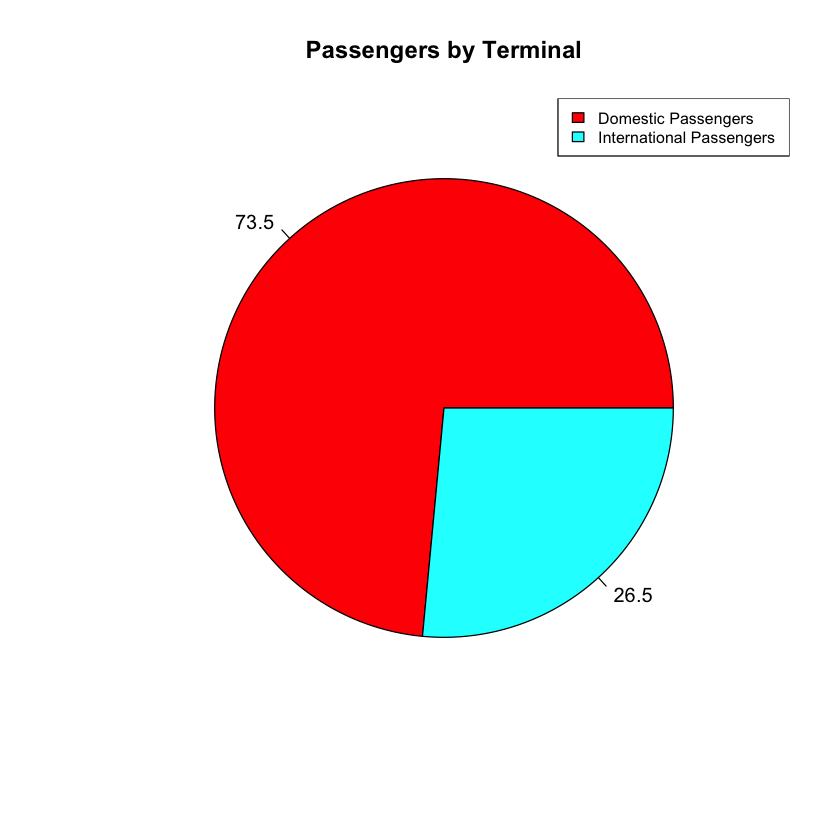

```r
# Total percentage of passenger uses Domestic terminal and International terminal

Passenger_dom<-sum(airlines[airlines$Terminal=="Terminal 2",c("Passenger.Count")])
Passenger_int<-sum(airlines[airlines$Terminal=="International",c("Passenger.Count")])

#airlines$Passenger.Count

x<-c(Passenger_dom,Passenger_int)
piepercent<- round(100*x/sum(x), 1)

pie(x, labels = piepercent, main = "Passengers by Terminal",col = rainbow(length(x)))
legend("topright", c("Domestic Passengers","International Passengers"), cex = 0.8,
   fill = rainbow(length(x)))
```

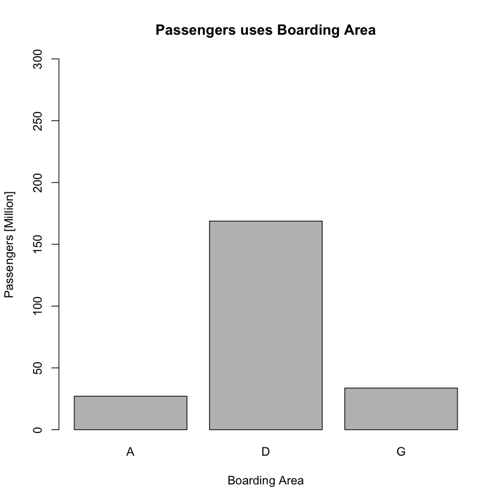

```r
# Boarding Area

boarding_area_A<- sum(airlines[airlines$Boarding.Area=="A",c("Passenger.Count")])
boarding_area_D<- sum(airlines[airlines$Boarding.Area=="D",c("Passenger.Count")])
boarding_area_G<- sum(airlines[airlines$Boarding.Area=="G",c("Passenger.Count")])



v<-c(boarding_area_A,boarding_area_D,boarding_area_G)
v<-v/1000000
M <- c("A","D","G")
barplot(v,names.arg=M,ylim = c(0,300),xlab="Boarding Area",ylab="Passengers [Million]",
main="Passengers uses Boarding Area")
```

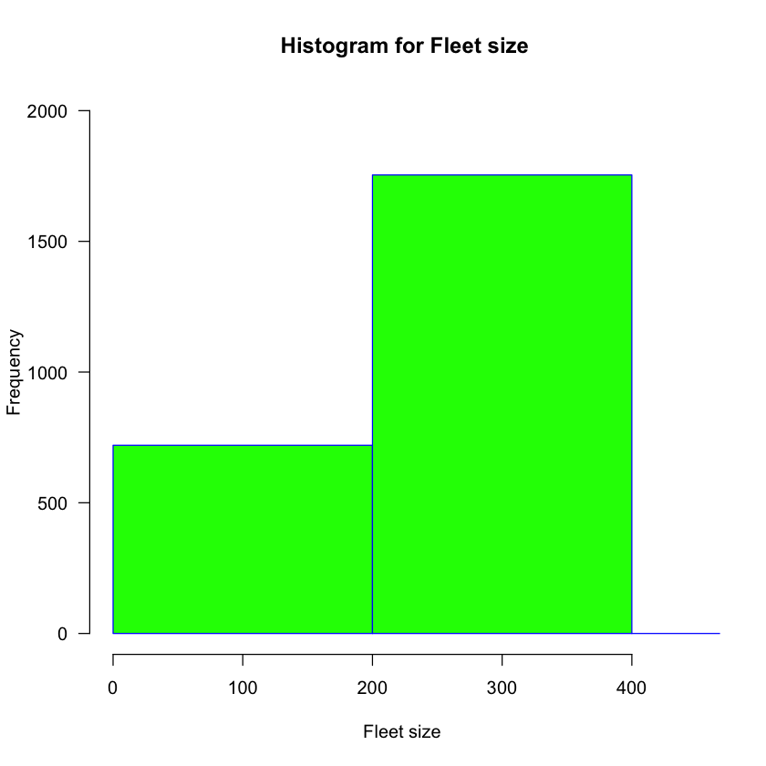

```r
hist(airlines$Fleet.Size,
     main="Histogram for Fleet size",
     xlab="Fleet size ",
     border="blue",
     col="green",
     xlim=c(0,450),
     ylim=c(0,2000),
     las=1,
     breaks=5)
```

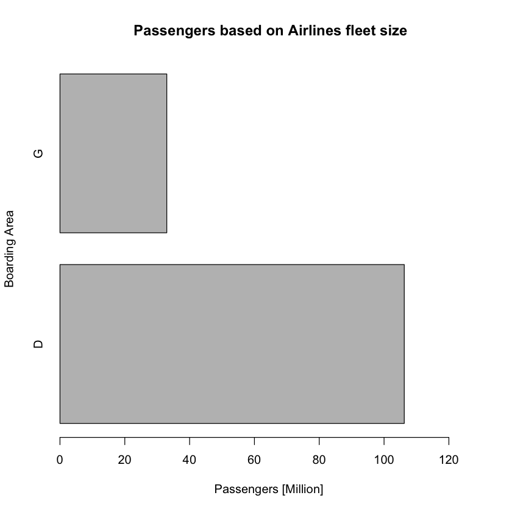

```r
# fleet size 200 to 400 airlines usese terminal
boarding_area_A1<-sum(airlines[airlines$Fleet.Size>199 & airlines$Boarding.Area=="A" ,c("Passenger.Count")])

boarding_area_D1<-sum(airlines[airlines$Fleet.Size>199 & airlines$Boarding.Area=="D" ,c("Passenger.Count")])
boarding_area_G1<-sum(airlines[airlines$Fleet.Size>199 & airlines$Boarding.Area=="G" ,c("Passenger.Count")])

y1<-c(boarding_area_D1/1000000,boarding_area_G1/1000000)
barplot(y1, main="Passengers based on Airlines fleet size", horiz=TRUE, xlim = c(0,130),xlab="Passengers [Million] ",ylab="Boarding Area",
  names.arg=c("D", "G"))
```

# 8. Summery:

The datasets provide a good insight into SFO passengers, airlines landings, airlines, and country. The dataset is reliable. Therefore, the chance to get the most optimal solution for small projects is moderate. The dataset has been segmented using country, passengers, fleet size, terminal, and boarding area. Together with all characteristics, it is possible to make a suggestion regarding SFO expansion necessities.

The histrogram represents the airlines fleet size frequency. The fleet size range 200 to 400 has the highest frequency. The highest fleet size occupies the maximum spaces of SFO. We have esimated the maximum fleet size airlines that passengers to the different boarding area. If we know that the maximum used boarding area by passengers , we can assume the mentioned boarding area requires expansion.

# 9. Recommendations:

These are the following recommendation where SFO needs expansion:  
1. The Domestic terminal (Terminal 2) needs expansion because it carries most of the domestic passengers.  
2. The international terminal which arries almost 26.5% passengers.  
3. The boarding area D that is used by more than 150 million passengers.